# Review and Confidence Intervals

Week 4

Published

January 30, 2025

# Before we start

- Congrats passing through the first quiz! How are you feeling?
- Grades for the psets are out.

[Download script](https://artur-baranov.github.io/nu-ps405-ds/scripts/ps405-d_4.qmd)

[Download data](https://artur-baranov.github.io/nu-ps405-ds/data/sipri.csv)

# Review of the previous week

**Review**

Start with loading the `tidyverse` library and the World Happiness Report data.

```r
library(tidyverse)

whr = read.csv("data/WHR.csv")
```

How is the `Continent` associated with happiness (`Ladder_score`)? Set up the linear model and present the regression output.

```r
...
```

Load the `ggeffects` library.

```r
...
```

Using `ggpredict()` plot the model.

```r
...(model) %>%
  ...()
```

Using `relevel()` transform the `Continent` variable so the `North America` becomes a reference category. Don’t forget that the variable should be of class factor!

```r
...
```

Run the model again, present the output.

```r
...
```

Draw the plot to gain a better understanding of what’s going on. What has changed? Why does the result look different?

```r
...
```

# Review of the homework

- Don’t load data multiple times
- Don’t leave `install.packages()` when you render the script
- Don’t forget to use `stars = TRUE` for `modelsummary()`

## $\LaTeX$ issues

Integration of R, Python, markdown, Latex and other useful languages incredibly useful. But it comes to a price that researchers should be careful. Any $\LaTeX$ code should go within two `$` dollar signs `$`. For example, an inline formula looks like this: $ Y = 10 $, which produces the following result: $Y = 10$. Alternatively, you can use a double dollar sign to start a “chunk” for latex. For example:

$$Y = \beta_0 + \beta_1X + u$$

## Useful functions

Sometimes you might want to visualize some mathematical functions using `geom_function()`. In the HW, you were asked to plot an OLS regression vs the true data generating process. For this purpose example below is super useful (however, `geom_abline()` for this particular task is perfect, too).

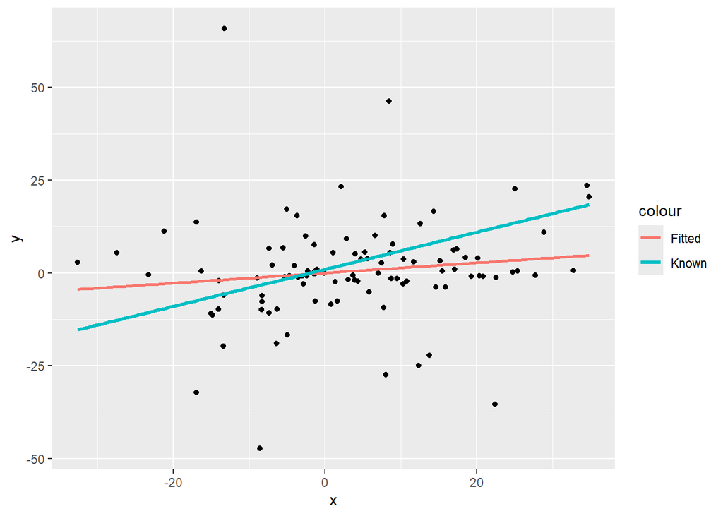

```r
set.seed(123)

example_data = data.frame(x = rnorm(100,
                                    mean = 2,
                                    sd = 15),
                          y = rnorm(100,
                                    mean = 2,
                                    sd = 15) * rnorm(100))

ggplot(example_data, aes(x = x, y = y)) +
  geom_point() +
  geom_smooth(aes(color = "Fitted"), method = "lm", se = F) +
  geom_function(aes(color = "Known"), fun = function(x){1 + 0.5 * x}, size = 1.2)
```

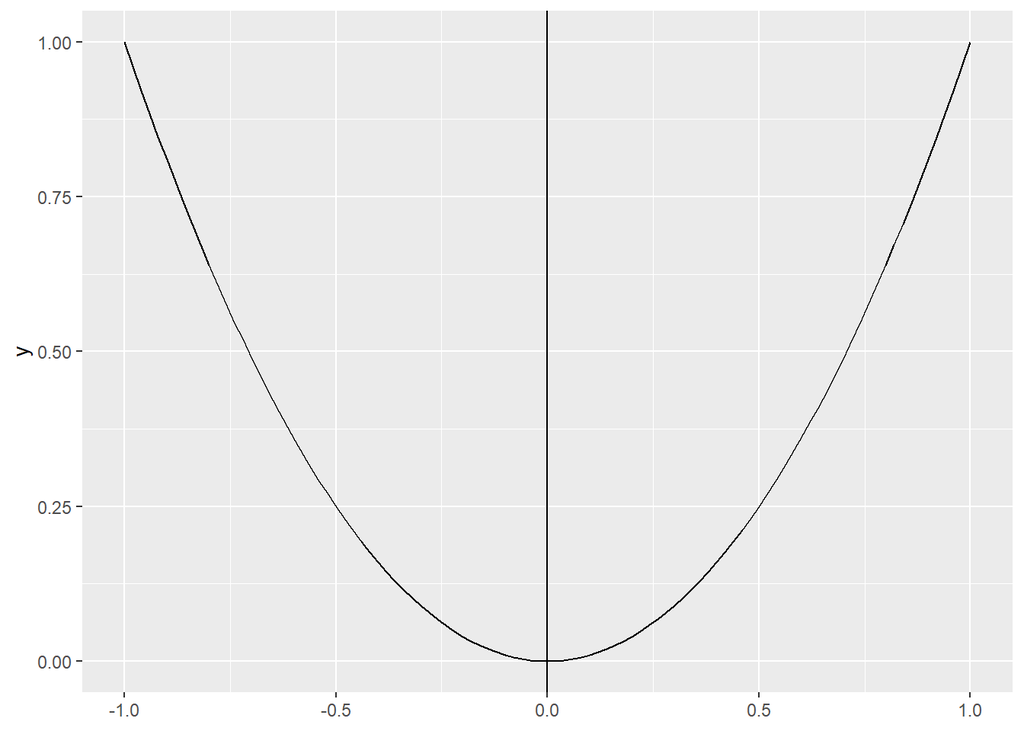

```r
ggplot() +
  geom_function(fun = function(x){x^2}) +
  geom_vline(xintercept = 0) +
  xlim(-1, 1)
```

# Agenda

- Go over hard concepts: fixed effects, interactions and transformations
- Refreshing confidence intervals

# Right hand side extensions

Today we are again working with WhoGov dataset. As usual, take a look at the [codebook](https://politicscentre.nuffield.ox.ac.uk/media/4117/whogov_codebook.pdf).

These are the following variables we are going to work with:

- `country_name` is a country name
- `n_individuals` number of unique persons in the cabinet
- `leaderexperience_continuous` the number of years the person has been leader of the country in total.
- `leader_party` party of the leader

```r
whogov = read.csv("data/WhoGov.csv")
```

## Fixed Effects

When we introduce a dummy variable into the model, we quite often are interested in controlling for unobserved heterogeneity by allowing each category to have its own intercept. This is referred to as **fixed effects**.

First, let’s create a dummy variable indicating if a leader is independent or Partisan. You can use 1 or 0 instead, but to make it more readable here we stick to more transparent labels.

```r
whogov = whogov %>%
  mutate(indep = ifelse(leader_party == "independent", "Independent", "Partisan"))
```

Don’t forget about the class of the variable!

```r
whogov$indep = as.factor(whogov$indep)
```

Take a moment to think about what unobserved heterogeneity we can control for by including whether a leader is independent or partisan in the model.

```r
model_fe = lm(n_individuals ~ leaderexperience_continuous + indep, whogov)
summary(model_fe)
```

```
Call:
lm(formula = n_individuals ~ leaderexperience_continuous + indep,
    data = whogov)

Residuals:
    Min      1Q  Median      3Q     Max
-29.437  -7.078  -1.796   5.377 108.632

Coefficients:
                            Estimate Std. Error t value Pr(>|t|)
(Intercept)                 20.98188    0.30295   69.26   <2e-16 ***
leaderexperience_continuous  0.35700    0.01617   22.08   <2e-16 ***
indepPartisan                3.02909    0.29988   10.10   <2e-16 ***
---
Signif. codes:  0 '***' 0.001 '**' 0.01 '*' 0.05 '.' 0.1 ' ' 1

Residual standard error: 11.06 on 9126 degrees of freedom
  (24 observations deleted due to missingness)
Multiple R-squared:  0.05649,   Adjusted R-squared:  0.05628
F-statistic: 273.2 on 2 and 9126 DF,  p-value: < 2.2e-16
```

Let’s relevel to get the results for Independent candidates.

```r
whogov$indep = relevel(whogov$indep, ref = "Partisan")
model_fe = lm(n_individuals ~ leaderexperience_continuous + indep, whogov)
summary(model_fe)
```

```
Call:
lm(formula = n_individuals ~ leaderexperience_continuous + indep,
    data = whogov)

Residuals:
    Min      1Q  Median      3Q     Max
-29.437  -7.078  -1.796   5.377 108.632

Coefficients:
                            Estimate Std. Error t value Pr(>|t|)
(Intercept)                 24.01096    0.16605  144.60   <2e-16 ***
leaderexperience_continuous  0.35700    0.01617   22.08   <2e-16 ***
indepIndependent            -3.02909    0.29988  -10.10   <2e-16 ***
---
Signif. codes:  0 '***' 0.001 '**' 0.01 '*' 0.05 '.' 0.1 ' ' 1

Residual standard error: 11.06 on 9126 degrees of freedom
  (24 observations deleted due to missingness)
Multiple R-squared:  0.05649,   Adjusted R-squared:  0.05628
F-statistic: 273.2 on 2 and 9126 DF,  p-value: < 2.2e-16
```

To understand what’s going on in the model we might want to visualize the result. Load the `ggeffects` library.

```r
library(ggeffects)
```

Then, visualize the result. What can we see?

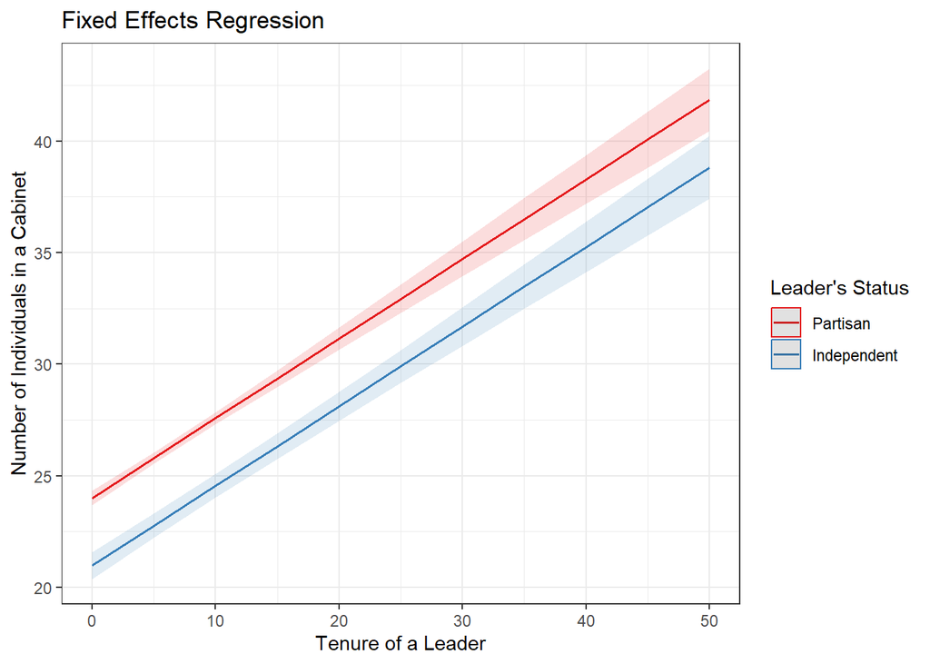

```r
ggpredict(model_fe, terms = c("leaderexperience_continuous", "indep")) %>%
  plot() +
  labs(title = "Fixed Effects Regression",
       x = "Tenure of a Leader",
       y = "Number of Individuals in a Cabinet",
       color = "Leader's Status") +
  theme_bw()
```

## Interactions

Often dummy variables are used to introduce an interaction term in the model. We will explore the association between `Perceptions_of_corruption` and number of people in the cabinet (`n_individuals`) depending on the independence of the party leader.

The task isn’t trivial as now we planning to use data from two datasets, Let’s subset those.

```r
whr_subset = whr %>%
  select(Country_name, Perceptions_of_corruption)

whogov_subset = whogov %>%
  filter(year == 2021) %>%
  select(country_name, n_individuals, indep)
```

Now, we are merging them. Once again, there is a great resource for [joins](https://thomasadventure.blog/posts/r-merging-datasets/) (check “the {dplyr} way”)!

```r
whr_whogov = whr_subset %>%
  left_join(whogov_subset, by = c("Country_name" = "country_name"))
```

Check the result of the `left_join()`

```r
head(whr_whogov)
```

```
  Country_name Perceptions_of_corruption n_individuals    indep
1      Finland                     0.182            23 Partisan
2      Denmark                     0.196            24 Partisan
3      Iceland                     0.668            15 Partisan
4       Israel                     0.708            33 Partisan
5  Netherlands                     0.379            18 Partisan
6       Sweden                     0.202            26 Partisan
```

Now, let’s interact the variable

```r
model_in = lm(Perceptions_of_corruption ~ n_individuals * indep, whr_whogov)
summary(model_in)
```

```
Call:
lm(formula = Perceptions_of_corruption ~ n_individuals * indep,
    data = whr_whogov)

Residuals:
     Min       1Q   Median       3Q      Max
-0.54000 -0.05737  0.04300  0.10864  0.24382

Coefficients:
                                Estimate Std. Error t value Pr(>|t|)
(Intercept)                     0.575192   0.061646   9.331 5.59e-16 ***
n_individuals                   0.004818   0.002151   2.240   0.0269 *
indepIndependent                0.386220   0.159570   2.420   0.0170 *
n_individuals:indepIndependent -0.010703   0.005501  -1.946   0.0540 .
---
Signif. codes:  0 '***' 0.001 '**' 0.01 '*' 0.05 '.' 0.1 ' ' 1

Residual standard error: 0.1737 on 123 degrees of freedom
  (10 observations deleted due to missingness)
Multiple R-squared:  0.08324,   Adjusted R-squared:  0.06088
F-statistic: 3.723 on 3 and 123 DF,  p-value: 0.01326
```

Let’s plot the result.

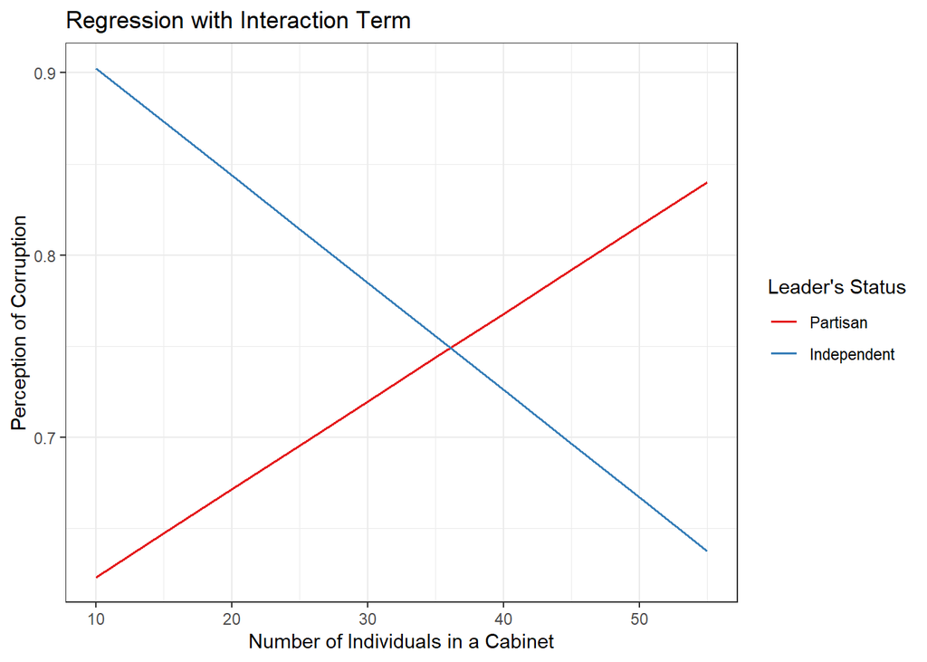

```r
ggpredict(model_in, terms= c("n_individuals", "indep")) %>%
  plot(show_ci = FALSE) +
  labs(title = "Regression with Interaction Term",
       x = "Number of Individuals in a Cabinet",
       y = "Perception of Corruption",
       color = "Leader's Status") +
  theme_bw()
```

I guess after solving pset and quiz you realize why interpreting interactions is hard? You can easily simulate the data (i.e., calculate the marginal effect) using `ggpredict()`. For example,

```r
ggpredict(model_in, terms= c("n_individuals [12]", "indep [Independent]"))
```

```
# Predicted values of Perceptions_of_corruption

n_individuals | Predicted |     95% CI
--------------------------------------
           12 |      0.89 | 0.71, 1.07
```

## IV Transformations

One of the assumptions for OLS is that there is a linear relationship between the dependent and independent variables. However, this quite often not the case. Let’s reverse the correction made in World Happiness report data. See below. Does it look linear?

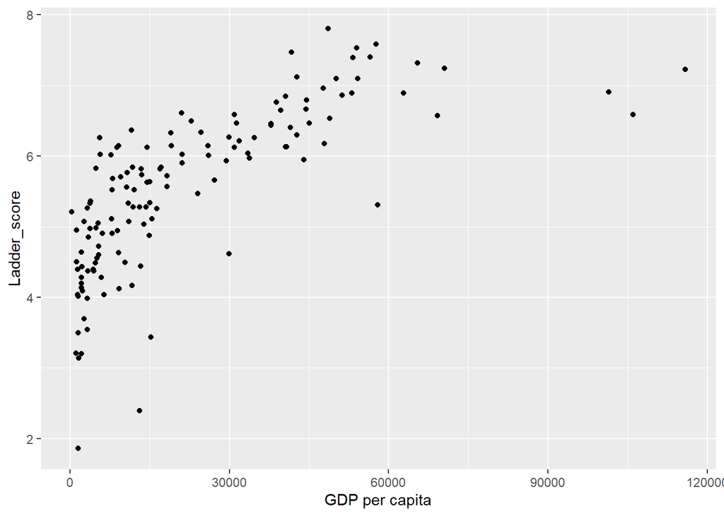

```r
ggplot(whr) +
  geom_point(aes(x = exp(Logged_GDP_per_capita), y = Ladder_score)) +
  labs(x = "GDP per capita")
```

It doesn’t. It’s hard to describe this relationship in a linear manner. Natural log would explain this better, right?

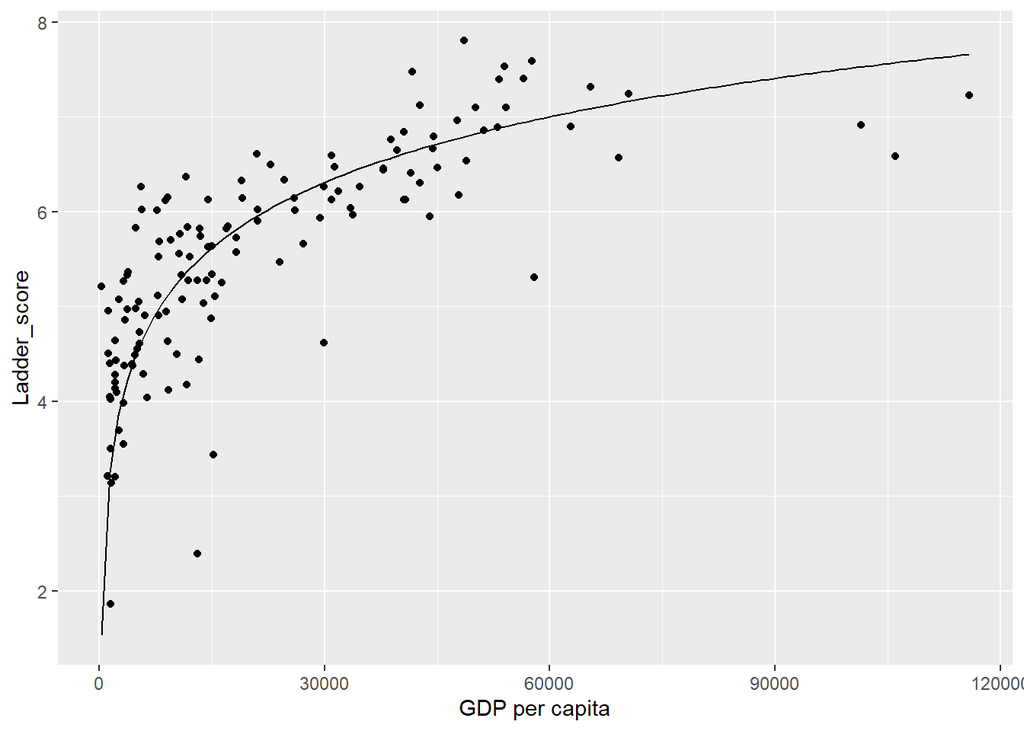

```r
ggplot(whr, aes(x = exp(Logged_GDP_per_capita), y = Ladder_score)) +
  geom_point() +
  geom_function(fun = function(x){log(x) - 4}) +
  labs(x = "GDP per capita")
```

This is why we use the natural logarithm to transform GDP per capita. The transformation reveals a linear relationship between the two variables, allowing us to capture non-linear patterns in a linear format when using OLS regression. Another commonly used transformation is quadratic ($x^2$), which serves the same purpose of addressing non-linear relationships. We call latter ones **polynomials**.

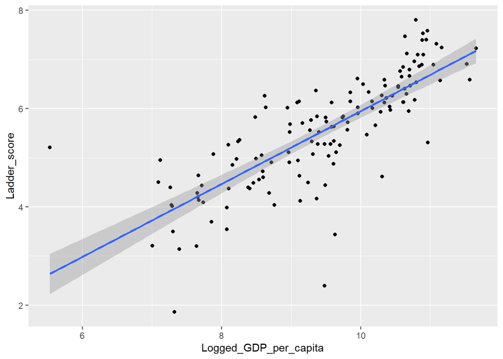

```r
ggplot(whr, aes(x = Logged_GDP_per_capita, y = Ladder_score)) +
  geom_point() +
  geom_smooth(method = "lm")
```

# Confidence Intervals

Intuition is straightforward: it’s a range within which the true value lies, with a given probability, typically 95%.

For example, we simulate the data from two different distributions (although, both are normal). The distribution X has the true $\mu$ equal to 0, whereas distribution Y has $\mu = 2$. Let’s plot it! Are these distributions different?

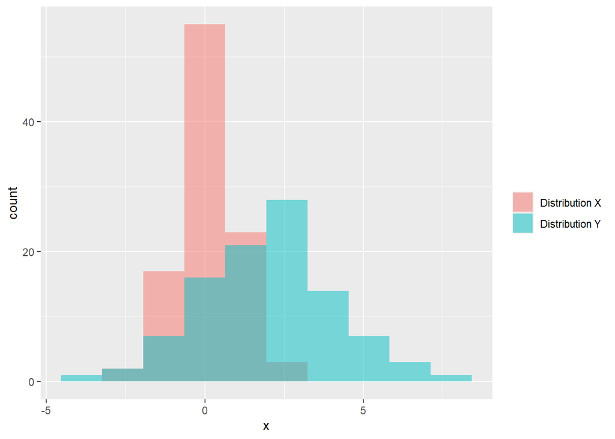

```r
set.seed(123)
x = rnorm(100,
          mean = 0,
          sd = 1)

set.seed(111)
y = rnorm(100,
          mean = 2,
          sd = 2)

ggplot() +
  geom_histogram(aes(x = x, fill = "Distribution X"), alpha = 0.5, bins = 10) +
  geom_histogram(aes(x = y, fill = "Distribution Y"), alpha = 0.5, bins = 10) +
  labs(fill = "")
```

# Hypothesis test

Don’t make inferences based solely on the plots!

```r
t.test(x, y)
```

```
    Welch Two Sample t-test

data:  x and y
t = -8.0922, df = 133.82, p-value = 3.15e-13
alternative hypothesis: true difference in means is not equal to 0
95 percent confidence interval:
 -2.344424 -1.423488
sample estimates:
 mean of x  mean of y
0.09040591 1.97436188
```

Now, let’s visualize their confidence intervals. First, we simply create a dataframe for our convenience

```r
x_distribution = data.frame(value = x,
                            distribution = "X distribution")

y_distribution = data.frame(value = y,
                            distribution = "Y distribution")

xy_distirbutions = rbind(x_distribution, y_distribution)

head(xy_distirbutions)
```

```
        value   distribution
1 -0.56047565 X distribution
2 -0.23017749 X distribution
3  1.55870831 X distribution
4  0.07050839 X distribution
5  0.12928774 X distribution
6  1.71506499 X distribution
```

Then, let’s calculate statistics. You should spend some time looking through this code and match it with the slides!

```r
ci_xy = xy_distirbutions %>%
  group_by(distribution) %>%
  summarize(
      mean_value = mean(value, na.rm = TRUE),
      lower = mean_value - 1.96 * sd(value, na.rm = TRUE) / sqrt(n()),
      upper = mean_value + 1.96 * sd(value, na.rm = TRUE) / sqrt(n()))

ci_xy
```

```
# A tibble: 2 × 4
  distribution   mean_value   lower upper
  <chr>               <dbl>   <dbl> <dbl>
1 X distribution     0.0904 -0.0885 0.269
2 Y distribution     1.97    1.55   2.39
```

Finally, visualize the confidence intervals

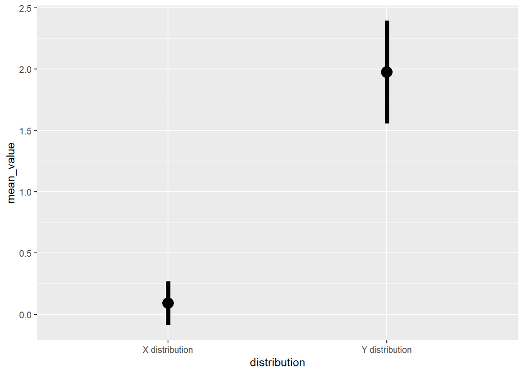

```r
ggplot(ci_xy) +
  geom_linerange(aes(x = distribution,
                     ymin = lower,
                     ymax = upper),
                 size = 2) +
  geom_point(aes(x = distribution,
                 y = mean_value),
             size = 5)
```

# Exercises

We are working with [SIPRI Arms Transfers Database](https://www.sipri.org/databases/armstransfers). It contains information on all transfers of major conventional arms.

First, load it.

**Solution**

```r
sipri = ...
```

Draw a histogram of `Import` variable

**Solution**

```r
...
```

Using `table()` check the `Regime` variable.

**Solution**

YOUR SOLUTION HERE

Check the `class()` of the `Regime` variable. Is it correct? Explain. Correct if needed.

**Solution**

YOUR SOLUTION HERE

Using `filter()`, leave only `Autocratic` type of `Regime` and save to `autocracies_import` dataframe.

**Solution**

```r
autocracies_import = ...
```

Using `filter()`, leave only `Democratic` type of `Regime` and save to `democracies_import` dataframe.

**Solution**

```r
autocracies_import = ...
```

Using `rbind()`, bind the rows of `autocracies_import` and `democracies_import` dataframes. Save it to a new dataframe `autdem_import`.

**Solution**

```r
autdem_import = ...
```

Draw a boxplot (`geom_boxplot()`), where X is `Regime`, and Y is `Import`. What can you see? Are these groups different?

**Solution**

```r
autdem_import %>%
  ggplot() ...
```

Now, let’s caulculate a confidence interval. First, `group_by()` by the `Regime` type, and `summarize()` average `Import` in democracies and autocracies, and lower and upper bounds of confidence interval. Assume the variables are distributed normally.

**Solution**

```r
ci_autdem = autdem_import %>%
  group_by(...) %>%
  ...(
      mean_value = ...(..., na.rm = TRUE),
      lower = mean_value - 1.96 * sd(..., na.rm = TRUE) / sqrt(n()),
      upper = ... + 1.96 * sd(..., na.rm = TRUE) / sqrt(n()))
```

Visualize the confidence intervals using `geom_linerange()` and `geom_point()`. Are these distributions different?

**Solution**

```r
ggplot(...) +
  ...(...) +
  geom_point(aes(x = ...,
                 y = mean_value))
```

Finally, to double check the conclusion, run the `t.test()`. What is your final say? Are arms imports in democracies and autocracies different? Why?

**Solution**

```r
...
```

# Check List

I know how to introduce fixed effects, interactions and polynomials to the linear model

I know how to simulate the results of fixed effects and interactions

I know what the confidence interval is

I know how to test whether two distributions are different